# Text Analysis of Hamlet

Yutong Song

20/11/2020

**Note**: This `rmarkdown` file has been uploaded to https://github.com/yytsong/challenge-hamlet. If you have any questions about this report, please email yuri.songyt@gmail.com.

# 1 Prepare Hamlet text

Step 1: Load text file into the session and inspect - Use `read_delim` to load the txt file into the session, and remove the character introduction part - Define column names and added new labeling column for **ACT** and **SCENE** - Fill down for character, act, and scene to complete the label - Inspect the head of the tibble

```r
setwd("~/Dropbox/challenge-hamlet/data")
hamlet <- read_delim(file = "hamlet.txt", delim = "\t",col_names = FALSE, skip = 77)  %>%
  rename("character" = "X1", "text" = "X2") %>%
  mutate(
    act = case_when(
      str_detect(character, pattern = "ACT ") ~ character,
      text == "HAMLET" ~ text,
      TRUE ~ NA_character_),
    scene = case_when(
      str_detect(character, pattern = "ACT |SCENE ") ~ character,
      text == "HAMLET" ~ text,
      TRUE ~ NA_character_),
    character = ifelse(text == "HAMLET", "play_title", str_remove(character, pattern = ":"))
    ) %>%
  fill(act, .direction = "down") %>%
  fill(character, .direction = "down") %>%
  fill(scene, .direction = "down")

# Inspection
head(hamlet)
```

```
## # A tibble: 6 x 4
##   character  text                                           act    scene
##   <chr>      <chr>                                          <chr>  <chr>
## 1 play_title HAMLET                                         HAMLET HAMLET
## 2 play_title <NA>                                           ACT I  ACT I
## 3 SCENE I    Elsinore. A platform before the castle.        ACT I  SCENE I
## 4 SCENE I    [FRANCISCO at his post. Enter to him BERNARDO] ACT I  SCENE I
## 5 BERNARDO   Who's there?                                   ACT I  SCENE I
## 6 FRANCISCO  Nay, answer me: stand, and unfold yourself.    ACT I  SCENE I
```

Step 2: Further filter out unnecessary lines, where lines highlighted entrance and exeunt, or a line only contain “|”.

Sometime, a description goes through multiples where open and close square brackets are not in the same line. Occasionally, a line may include a sentence and a description. The target is to remove all act descriptions (e.g. entrance and exeunt) without removing any sentences.

```r
remove_desc_hamlet <- hamlet %>%
  mutate(
    text = case_when(
      str_detect(text, pattern = "\\[") &
        str_detect(text, pattern = "\\]", negate = TRUE) ~ str_c(text, "]"),
      str_detect(text, pattern = "\\]") &
        str_detect(text, pattern = "\\[", negate = TRUE) ~ str_c("[", text),
      TRUE ~ text
    ),
    # create a new column that remove less meaningful lines and trim the white spaces
    new_text = str_remove_all(text, pattern = "\\[.*\\]") %>% trimws(., which = "both")
  ) %>%
  # remove empty or "not said" lines
  filter(!(new_text %in% c("", "|")), !is.na(new_text), character != "play_title") %>%
  select(-text) %>%
  rename("text" = "new_text")

# Inspection
head(remove_desc_hamlet)
```

```
## # A tibble: 6 x 4
##   character act   scene   text
##   <chr>     <chr> <chr>   <chr>
## 1 SCENE I   ACT I SCENE I Elsinore. A platform before the castle.
## 2 BERNARDO  ACT I SCENE I Who's there?
## 3 FRANCISCO ACT I SCENE I Nay, answer me: stand, and unfold yourself.
## 4 BERNARDO  ACT I SCENE I Long live the king!
## 5 FRANCISCO ACT I SCENE I Bernardo?
## 6 BERNARDO  ACT I SCENE I He.
```

```r
remove_desc_hamlet %>%
  filter(str_detect(character, pattern = "SCENE ", negate =  TRUE)) %>%
  group_by(act, scene) %>%
  summarise(num_of_character = n_distinct(character)) %>%
  ungroup() %>%
  select(-act) %>%
  kbl() %>%
  kable_styling(
    bootstrap_options = c("striped", "hover", "condensed", "responsive"),
    full_width = F
  ) %>%
  pack_rows("ACT I", 1, 5) %>%
  pack_rows("ACT II", 6, 7) %>%
  pack_rows("ACT III", 8, 11) %>%
  pack_rows("ACT IV", 12, 18) %>%
  pack_rows("ACT V", 19, 19) %>%
  scroll_box(width = "100%", height = "400px")
```

| scene | num_of_character |
| --- | --- |
| **ACT I** |  |
| SCENE I | 4 |
| SCENE II | 9 |
| SCENE III | 3 |
| SCENE IV | 3 |
| SCENE V | 4 |
| **ACT II** |  |
| SCENE I | 3 |
| SCENE II | 8 |
| **ACT III** |  |
| SCENE I | 7 |
| SCENE II | 14 |
| SCENE III | 5 |
| SCENE IV | 4 |
| **ACT IV** |  |
| SCENE I | 2 |
| SCENE II | 3 |
| SCENE III | 3 |
| SCENE IV | 4 |
| SCENE V | 7 |
| SCENE VI | 3 |
| SCENE VII | 4 |
| **ACT V** |  |
| SCENE I | 4 |

# 2 The number of lines said per character

Step 1: identify the location of uncommon lines said by “All”, and spotted only ACT I/III SCENE II have clause with “All”.

```r
# inspect "All" involve which scene
remove_desc_hamlet %>%
  filter(character == "All")
```

```
## # A tibble: 2 x 4
##   character act     scene    text
##   <chr>     <chr>   <chr>    <chr>
## 1 All       ACT I   SCENE II Our duty to your honour.
## 2 All       ACT III SCENE II Lights, lights, lights!
```

Step 2: Find characters involved in these lines to correct the number of lines per character involved, I did visually find who were involved in the “All” saying.

```r
hamlet %>%
  filter(act %in% c("ACT I", "ACT III"), scene == "SCENE II") %>%
  mutate(label = ifelse(character == "All", "Keep", NA_character_)) %>%
  group_by(act, scene) %>%
  fill(label, .direction = "up") %>%
  filter((label == "Keep" &
            str_detect(text, pattern = "\\[|\\]")) |
           (character == "All")) %>%
  select(-label)
```

```
## # A tibble: 32 x 4
## # Groups:   act, scene [2]
##    character     text                                             act    scene
##    <chr>         <chr>                                            <chr>  <chr>
##  1 SCENE II      "[Enter KING CLAUDIUS, QUEEN GERTRUDE, HAMLET,"  ACT I  SCENE …
##  2 SCENE II      "and Attendants]"                                ACT I  SCENE …
##  3 KING CLAUDIUS "[Exeunt VOLTIMAND and CORNELIUS]"               ACT I  SCENE …
##  4 HAMLET        "[Aside]  A little more than kin, and less than… ACT I  SCENE …
##  5 KING CLAUDIUS "[Exeunt all but HAMLET]"                        ACT I  SCENE …
##  6 HAMLET        "[Enter HORATIO, MARCELLUS, and BERNARDO]"       ACT I  SCENE …
##  7 All           "                  Our duty to your honour."     ACT I  SCENE …
##  8 SCENE II      "[Enter HAMLET and Players]"                     ACT I… SCENE …
##  9 HAMLET        "[Exeunt Players]"                               ACT I… SCENE …
## 10 HAMLET        "[Enter POLONIUS, ROSENCRANTZ, and GUILDENSTERN… ACT I… SCENE …
## # … with 22 more rows
```

**Note**: I chose not to write a function to run through the lines to record who were still remained on stage by the time “All” lines arrived, considering visual inspection outcome (only two scene) and one time use of this script. If this task is repeatable or generalizable, then will recommend to write a function to loop through the lines.

Inspect entrance and exeunt for both scenes,

## 2.1 Results 1: Show the number of lines said per character throughout the play.

Hamlet read the most number of lines served the main character purposefully well. The following characters are sorted by descending order of number of lines each said throughout the play.

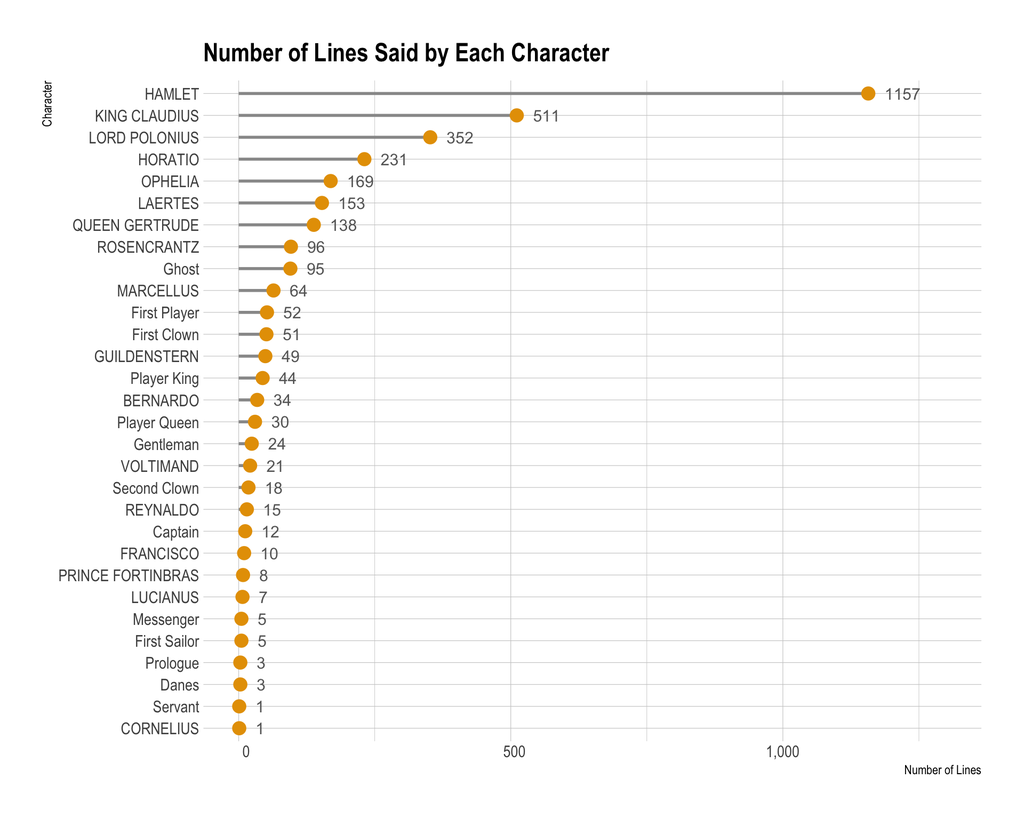

```r
line_df <- remove_desc_hamlet %>%
  group_by(character) %>%
  summarise(number_of_lines = n()) %>%
  ungroup() %>%
  # remove scene label lines
  filter(!str_detect(character, pattern = "SCENE |play_title|All")) %>%
  # adjust for the "All" said
  mutate(
    number_of_lines = case_when(
      character %in% c("HORATIO") ~ number_of_lines + 2L,
      character %in% c("HAMLET","MARCELLUS", "BARNARDO", "LUCIANUS", "OPHELIA") ~ number_of_lines + 1L,
      TRUE ~ number_of_lines
    )
  ) %>%
  arrange(desc(number_of_lines))

line_df %>%
  ggplot() +
  geom_segment(
    aes(
      x = reorder(character, number_of_lines),
      xend = reorder(character, number_of_lines),
      y = 0,
      yend = number_of_lines
    ),
    color = "#999999",
    size = 1
  ) +
  geom_point(aes(x = reorder(character, number_of_lines), y = number_of_lines),
             size = 4,
             color = "#E69F00") +
  geom_text_repel(
    aes(
      x = reorder(character, number_of_lines),
      y = number_of_lines,
      label = number_of_lines,
    ),
    color = "grey40",
    size = 4,
    nudge_y = 30,
    nudge_x = 0,
    direction = "y",
    hjust = 0,
    min.segment.length = 0,
    segment.color = 'transparent'
  ) +
  scale_y_continuous(labels=function(x) format(x, big.mark = ",", decimal.mark = ".", scientific = FALSE), limits = c(NA,1300)) +
  coord_flip() +
  theme_ipsum() +
  labs(title = "Number of Lines Said by Each Character",
       x = "Character",
       y = "Number of Lines")
```

## 2.2 Results 2: Show the number of lines said per character throughout the play by act and scene.

Further analysis are carried out by grouping of ACT and SCENE. Refer to the line chart, Hamlet does not have lines in every scene, and he had overwhelmingly more lines prior to ACT IV SCENE II (except ACT III SCENE III and few others). Comparing with Hamlet, OPHELIA and KING CLAUDIUS had more lines after that.

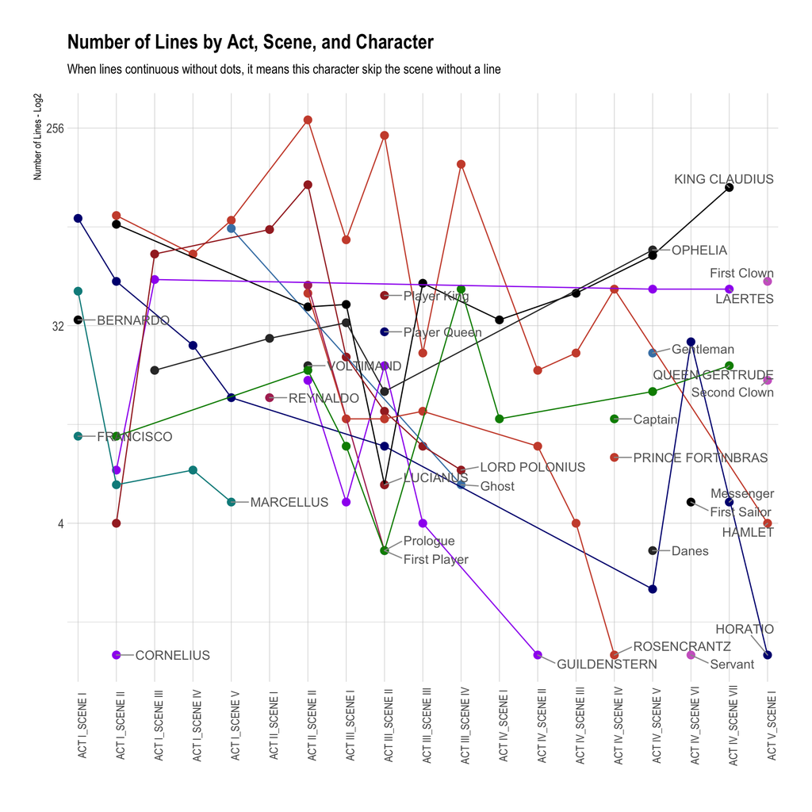

```r
a1s2 <-
  data.frame(
    character = c("HORATIO", "MARCELLUS", "BARNARDO"),
    add_line_1 = rep.int(1, 3),
    act = rep("ACT I", 3),
    scene = rep("SCENE II", 3)
  )
a3s2 <-
  data.frame(
    character = c("LORD POLONIUS"),
    add_line_2 = rep.int(1, 1),
    act = rep("ACT III", 1),
    scene = rep("SCENE II", 1)
  )


line_by_scene_df <- remove_desc_hamlet %>%
  filter(!str_detect(character, pattern = "SCENE |play_title|All")) %>%
  group_by(act, scene, character) %>%
  summarise(number_of_lines = n()) %>%
  ungroup() %>%
  left_join(a1s2) %>%
  left_join(a3s2) %>%
  mutate_at(vars(starts_with("add_line_")), ~ replace_na(., 0)) %>%
  mutate(number_of_lines = number_of_lines + add_line_1 + add_line_2) %>%
  arrange(desc(number_of_lines))  %>%
  mutate(group_ind = group_indices_(.data = ., .dots = "act", "scene")) %>%
  unite("act_scene",
        c("act", "scene"),
        sep = "_",
        remove = FALSE)

df_end <- line_by_scene_df %>%
  group_by(character) %>%
  filter(group_ind == max(group_ind)) %>%
  ungroup()


bpal2 <-
  rep (
    c(
      "tomato3",
      "brown",
      "black",
      "navy",
      "steelblue",
      "grey20",
      "purple",
      "orchid3",
      "maroon",
      "green4",
      "cyan4"
    ),
    3
  )


names(bpal2) <- unique(line_by_scene_df$character)
color_pallate <- bpal2[1:length(unique(line_by_scene_df$character))]


line_by_scene_df %>%
  ggplot(aes(
    x = act_scene,
    y = number_of_lines,
    group = character,
    color = character
  )) +
  geom_point(size = 3) +
  geom_line(na.rm = TRUE) +
  geom_text_repel(
    data = df_end,
    aes(label = character),
    color = "grey40",
    size = 4,
    nudge_y = 0,
    nudge_x = 0.5,
    direction = "y",
    hjust = 0,
    min.segment.length = 0,
    segment.color = 'grey60'
  ) +
  scale_x_discrete(expand = c(0.01, 0.10)) +
  scale_y_continuous(trans = "log2") +
  scale_color_manual(values = color_pallate) +
  theme_ipsum() +
  theme(legend.position = "none",
        axis.text.x = element_text(angle = 90, size = 10)) +
  labs(title = "Number of Lines by Act, Scene, and Character",
       subtitle = "When lines continuous without dots, it means this character skip the scene without a line",
       y = "Number of Lines - Log2",
       x = "")
```

# 3 A word cloud of unusual words

- Based on definition from Wikipedia, **term frequency–inverse document frequency (tf-idf)** has been calculated to identify importance of a word to a document in a collection or corpus.
- Source: https://en.wikipedia.org/wiki/Tf%E2%80%93idf
- In this scenario, each scene equals to a document in Hamlet collection.

Step 1: Transfer this data frame to a text-document format and remove descriptive rows.

```r
prepare_scene_text_df <-
  remove_desc_hamlet %>%
  filter(str_detect(character, pattern = "play_title|SCENE ", negate = TRUE)) %>%
  # combine ACT and SCENE to be one unique identifier of each document/scene
  unite("act_scene", act:scene, sep = "_", remove = TRUE) %>%
  select("doc_id" = act_scene, text)

head(prepare_scene_text_df)
```

```
## # A tibble: 6 x 2
##   doc_id        text
##   <chr>         <chr>
## 1 ACT I_SCENE I Who's there?
## 2 ACT I_SCENE I Nay, answer me: stand, and unfold yourself.
## 3 ACT I_SCENE I Long live the king!
## 4 ACT I_SCENE I Bernardo?
## 5 ACT I_SCENE I He.
## 6 ACT I_SCENE I You come most carefully upon your hour.
```

Step 2: Apply `tidytext` package (i.e. `unnest_tokens` and `stop_words`) to tokenize text and remove words that are commonly known as high frequency but contributes less to meanings of text. Followed, count occurance of each word in each scene.

```r
tokenized_df <- prepare_scene_text_df %>%
  unnest_tokens(word, text)  %>%
  anti_join(stop_words) %>%
  group_by(doc_id, word) %>%
  tally() %>%
  arrange(desc(n))

head(tokenized_df)
```

```
## # A tibble: 6 x 3
## # Groups:   doc_id [5]
##   doc_id           word      n
##   <chr>            <chr> <int>
## 1 ACT II_SCENE II  lord     44
## 2 ACT III_SCENE II lord     34
## 3 ACT I_SCENE V    lord     18
## 4 ACT II_SCENE I   lord     18
## 5 ACT III_SCENE II love     18
## 6 ACT I_SCENE II   lord     17
```

```r
# download data from lexicon package to remove spelling mistakes and optical character recognition (OCR)
data(grady_augmented)

ordered_tfidf <- tokenized_df %>%
  filter(word %in% grady_augmented) %>%
  bind_tf_idf(word, doc_id, n) %>%
  arrange(desc(tf_idf))  %>%
  ungroup() %>%
  top_n(., n=100, wt = tf_idf)

head(ordered_tfidf)
```

```
## # A tibble: 6 x 6
##   doc_id           word        n     tf   idf tf_idf
##   <chr>            <chr>   <int>  <dbl> <dbl>  <dbl>
## 1 ACT IV_SCENE II  sponge      3 0.0462  2.94 0.136
## 2 ACT IV_SCENE VI  letters     4 0.0513  1.56 0.0799
## 3 ACT V_SCENE I    gallows     4 0.0217  2.94 0.0640
## 4 ACT IV_SCENE VI  bless       2 0.0256  2.25 0.0577
## 5 ACT IV_SCENE VI  fellows     2 0.0256  2.25 0.0577
## 6 ACT IV_SCENE III fat         4 0.0222  2.25 0.0500
```

## 3.1 Result: Make a word cloud of unusual words in the script

Use a three color scheme, it is clearly the word **sponge** is the most rare word in Hamlet, followed by **letters**, **gallows** and a list of other words in lavender, and then the words in tomato color. The current word cloud shows the top 100 unusual words, and it can be expanded as request.

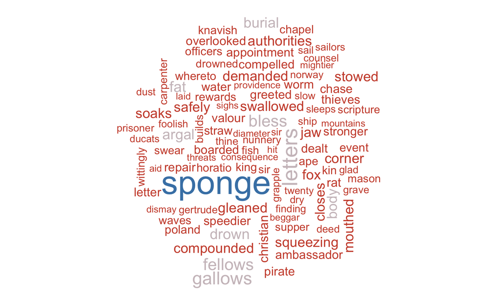

```r
wordcloud(ordered_tfidf$word, ordered_tfidf$tf_idf, #min.freq = 1,
          max.words = 100,
            colors = c("tomato3", "lavenderblush3","steelblue"))
```

**Note**: Also, `tm` and `qdap` packages are useful to convert this dataframe into a term document matrix. Choose term document matrix (TDM) because have more terms than scenes and it is easier to organize more rows than columns.

# 4 Compute the sentiment score for each scene.

I choose to apply two frameworks: Afinn and NRC, and compare their results.

## 4.1 Result 1: Sentiment Analysis by Afinn

- Afinn is a score-based dataset, which first column contains words and second column contains sentiment values between [-5, 5].
- Source https://github.com/fnielsen/afinn

```r
afinnsentiments = get_sentiments('afinn')
head(afinnsentiments, 10)
```

```
## # A tibble: 10 x 2
##    word       value
##    <chr>      <dbl>
##  1 abandon       -2
##  2 abandoned     -2
##  3 abandons      -2
##  4 abducted      -2
##  5 abduction     -2
##  6 abductions    -2
##  7 abhor         -3
##  8 abhorred      -3
##  9 abhorrent     -3
## 10 abhors        -3
```

The result shows that Hamlet is a tragedy by overwhelmingly negative sentiment scores throughout the place. Reached its lowest score -1.18 during ACT II SCENE I, while the highest was met during ACT IV_SCENE III 0.57. This play is overwhelmingly negative in sentiment.

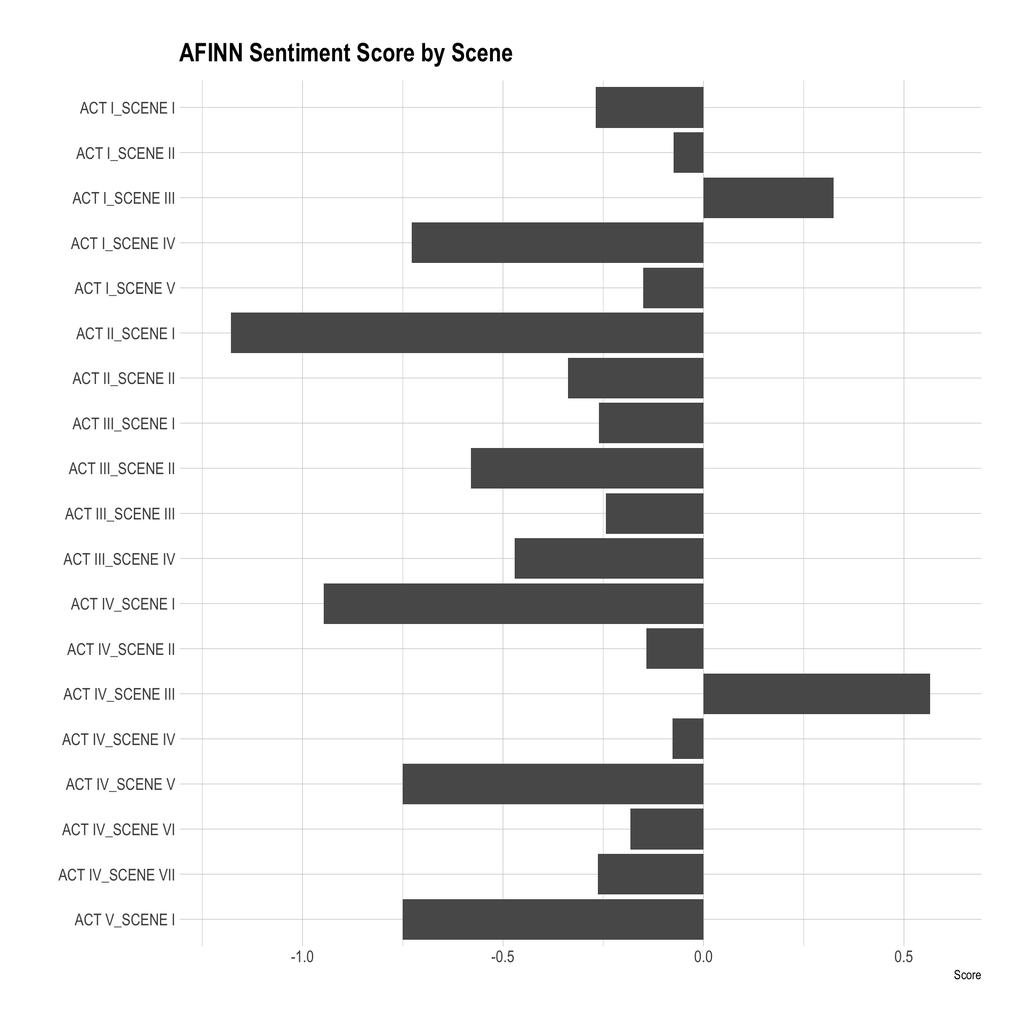

```r
afinn_df <-
  tokenized_df  %>%
  inner_join(afinnsentiments) %>%
  group_by(doc_id) %>%
  add_tally() %>%
  tally(mean(value)) %>%
  arrange(doc_id)


afinn_df %>%
  ggplot(aes(x = fct_rev(doc_id), y = n)) +
  geom_col()+
  theme_ipsum() +
  coord_flip() +
  labs(title = "AFINN Sentiment Score by Scene",
       x = "",
       y = "Score") +
  scale_y_continuous(expand = c(-0.5, 1))
```

## 4.2 Result 2: Sentiment Analysis by NRC

- NRC is a crowd sourced dataset. It contains eight basic emotions (anger, anticipation, disgust, fear, joy, sadness, surprise, and trust) and two sentiments (positive and negative).
- A big difference from Afinn is that a word can have multiple entries with different emotions attached to them.
- Source: https://saifmohammad.com/WebPages/NRC-Emotion-Lexicon.htm

```r
nrcsentiments = get_sentiments('nrc')
head(nrcsentiments)
```

```
## # A tibble: 6 x 2
##   word      sentiment
##   <chr>     <chr>
## 1 abacus    trust
## 2 abandon   fear
## 3 abandon   negative
## 4 abandon   sadness
## 5 abandoned anger
## 6 abandoned fear
```

```r
nrc_df <- tokenized_df %>%
  inner_join(nrcsentiments) %>%
  group_by(doc_id, sentiment) %>%
  summarise(n = sum(n)) %>%
  ungroup() %>%
  group_by(doc_id) %>%
  mutate(value = n / sum(n)) %>%
  ungroup() %>%
  mutate(value = scales::percent(value, accuracy = 0.01)) %>%
  select(-n) %>%
  pivot_wider(names_from = "sentiment", values_from = "value") %>%
  select(doc_id, positive, negative, everything(.)) %>%
  separate(col = doc_id,
           into = c("act", "scene"),
           sep = "_") %>%
  select(-act)

kbl(nrc_df) %>%
  kable_styling(
    bootstrap_options = c("striped", "hover", "condensed", "responsive"),
    full_width = F
  ) %>%
  add_header_above(c(
    " " = 1,
    "Sentiment" = 2,
    "Emotion" = 8
  )) %>%
  pack_rows("ACT I", 1, 5) %>%
  pack_rows("ACT II", 6, 7) %>%
  pack_rows("ACT III", 8, 11) %>%
  pack_rows("ACT IV", 12, 18) %>%
  pack_rows("ACT V", 19, 19) %>%
  scroll_box(width = "100%", height = "600px")
```

| scene | Sentiment positive | Sentiment negative | Emotion anger | Emotion anticipation | Emotion disgust | Emotion fear | Emotion joy | Emotion sadness | Emotion surprise | Emotion trust |
| --- | --- | --- | --- | --- | --- | --- | --- | --- | --- | --- |
| **ACT I** |  |  |  |  |  |  |  |  |  |  |
| SCENE I | 20.17% | 16.48% | 8.81% | 11.36% | 3.41% | 11.93% | 6.82% | 7.39% | 4.83% | 8.81% |
| SCENE II | 20.63% | 17.49% | 3.63% | 7.76% | 5.94% | 7.76% | 7.26% | 8.42% | 4.62% | 16.50% |
| SCENE III | 21.61% | 14.99% | 5.76% | 8.65% | 5.48% | 8.65% | 10.09% | 4.03% | 4.90% | 15.85% |
| SCENE IV | 22.49% | 20.71% | 5.92% | 5.92% | 9.47% | 11.24% | 5.92% | 4.73% | 1.78% | 11.83% |
| SCENE V | 18.42% | 18.05% | 8.08% | 6.58% | 9.40% | 11.09% | 6.58% | 5.64% | 4.89% | 11.28% |
| **ACT II** |  |  |  |  |  |  |  |  |  |  |
| SCENE I | 21.67% | 16.33% | 5.67% | 5.33% | 8.67% | 8.00% | 6.67% | 5.33% | 5.67% | 16.67% |
| SCENE II | 21.03% | 15.30% | 6.61% | 7.75% | 7.81% | 8.19% | 8.88% | 7.24% | 3.72% | 13.48% |
| **ACT III** |  |  |  |  |  |  |  |  |  |  |
| SCENE I | 20.24% | 14.88% | 6.75% | 6.75% | 7.74% | 9.52% | 7.94% | 8.73% | 4.37% | 13.10% |
| SCENE II | 22.64% | 16.18% | 4.18% | 7.27% | 7.36% | 6.64% | 9.55% | 7.55% | 4.55% | 14.09% |
| SCENE III | 16.19% | 18.62% | 8.50% | 8.10% | 6.48% | 9.31% | 7.69% | 8.50% | 4.05% | 12.55% |
| SCENE IV | 19.09% | 18.75% | 6.42% | 7.94% | 6.25% | 9.63% | 7.26% | 8.95% | 4.05% | 11.66% |
| **ACT IV** |  |  |  |  |  |  |  |  |  |  |
| SCENE I | 11.43% | 20.00% | 12.38% | 6.67% | 9.52% | 15.24% | 3.81% | 5.71% | 4.76% | 10.48% |
| SCENE II | 33.33% | 25.49% | 1.96% | 3.92% | 11.76% | 3.92% | 1.96% | NA | NA | 17.65% |
| SCENE III | 17.61% | 18.31% | 4.23% | 11.97% | 8.45% | 4.93% | 6.34% | 9.86% | 6.34% | 11.97% |
| SCENE IV | 22.54% | 13.29% | 6.36% | 9.83% | 5.20% | 10.98% | 6.36% | 5.78% | 4.05% | 15.61% |
| SCENE V | 17.67% | 13.38% | 5.83% | 9.61% | 5.49% | 9.43% | 9.78% | 8.06% | 6.52% | 14.24% |
| SCENE VI | 23.21% | 17.86% | 8.93% | 10.71% | 5.36% | 7.14% | 5.36% | 3.57% | 1.79% | 16.07% |
| SCENE VII | 17.28% | 16.82% | 6.91% | 9.68% | 6.91% | 8.53% | 6.68% | 8.53% | 5.99% | 12.67% |
| **ACT V** |  |  |  |  |  |  |  |  |  |  |
| SCENE I | 14.52% | 17.74% | 8.06% | 6.99% | 2.69% | 14.52% | 6.99% | 15.05% | 4.30% | 9.14% |

**Note**: Scroll up for the end of the table.

- The radar chart below showcased an example of using median score for each emotion through 19 scenes.
- Sentiment: “positive” and “negative” have been removed from this visualization.
- “Trust” came on top followed by “fear”.

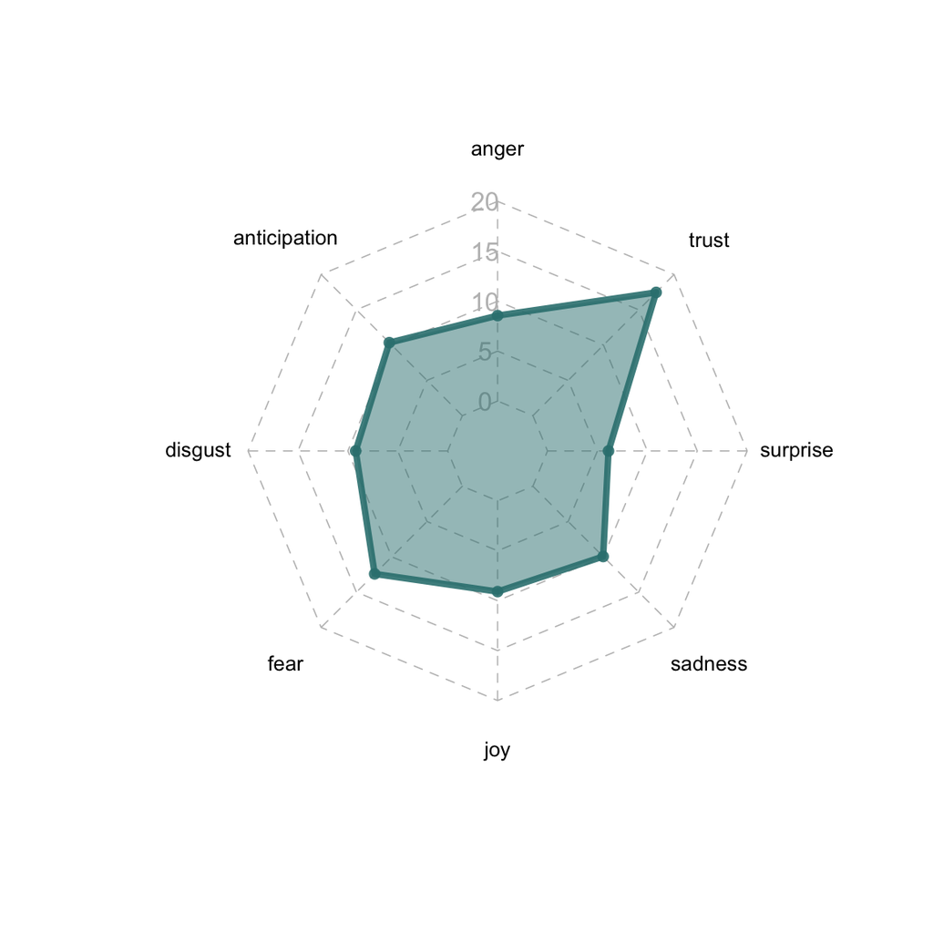

```r
radar_df <- tokenized_df %>%
  inner_join(nrcsentiments) %>%
  group_by(doc_id, sentiment) %>%
  summarise(n = sum(n)) %>%
  ungroup() %>%
  group_by(doc_id) %>%
  mutate(value = n / sum(n)) %>%
  ungroup() %>%
  select(-n) %>%
  pivot_wider(names_from = "sentiment", values_from = "value") %>%
  select(-c("positive", "negative")) %>%
  separate(col = doc_id,
           into = c("act", "scene"),
           sep = "_") %>%
  summarise_at(vars(anger:trust), ~ median(., na.rm = TRUE)) %>%
  rbind(rep(0.15,10), rep(0,10), .)

radarchart(
  radar_df,
  axistype = 1 ,
  pcol = rgb(0.2, 0.5, 0.5, 0.9) ,
  pfcol = rgb(0.2, 0.5, 0.5, 0.5) ,
  plwd = 4 ,
  cglcol = "grey",
  cglty = 2,
  axislabcol = "grey",
  caxislabels = seq(0, 20, 5),
  cglwd = 0.8,
  vlcex = 0.8
)
```

# 5 Summary

To conclude, this report addressed three key questions:

- Show the number of lines said per character throughout the play.

Highlight: I noticed the unusual line titled to “All” and adjust for the characters involved. Results have been presented using a lolliplot, and then in a line chart to show number of lines said by each character towards the timeline of the play.

- Make a word cloud of unusual words in the script

Highlight: I removed common stopwords, separated the play by scene (this can also be done by character), and apply tf-idf to calculate rareness of each word to the entire play. Outcome has been presented in a word cloud by request.

- Compute the sentiment score for each scene.

Highlight: I compared results by applying AFINN and NRC frameworks over the text tokens. Advantages of using AFINN includes but not limited to faster computation over larger datasets, and simple interpretable results. On the other hand, NRC offers additional eight dimensions of human-touch emotions, the result is more comprehensive and humanized. Results have been compared among a column chart, a table, and a radarchart.

# 6 Future Work

Additional character analysis can be carried out following the idea proposed in Nalisnick and Baird (2013), refer to reference 2. More sentiment frameworks can be tested, for instance, “bing” (positive / negative).

If analysis is carried out by less technical users, interactive visualization should be developed, and `Shiny` is a good complementary tool with this reports.

All suggestions are welcome.

# 7 Additional Reference

1. Basic Radar Chart. URL: https://www.r-graph-gallery.com/142-basic-radar-chart.html
2. Nalisnick, E. T., & Baird, H. S. (2013, August). Character-to-character sentiment analysis in Shakespeare’s plays. In Proceedings of the 51st Annual Meeting of the Association for Computational Linguistics (Volume 2: Short Papers) (pp. 479-483). URL: https://www.aclweb.org/anthology/P13-2085.pdf
3. Yann, R. (2020) A Short Guide to Historical Newspaper Data, Using R. URL: https://bookdown.org/yann_ryan/r-for-newspaper-data/calculating-tf-idf-scores-with-tidytext.html
4. Zhu, H. (2020). Create Awesome HTML Table with knitr::kable and kableExtra. URL: https://cran.r-project.org/web/packages/kableExtra/vignettes/awesome_table_in_html.html